# MEML_HW10_Soln

**Machine Learning for Mechanical Engineering**  
**Homework 10**  
**Due Tuesday, 06/23/2020, 9:30 AM**

TA: Taewan Kim  
Instructor: Prof. Seungchul Lee  
http://iai.postech.ac.kr/  
Industrial AI Lab at POSTECH

- For your handwritten solution, scan or take a picture of them.
- For your code, only .ipynb file will be graded.
  - Please write your NAME and student ID on your .ipynb files. ex) TaewanKim_HW10.ipynb
- Please compress all files to make a single .zip file
  - Please write your NAME and student ID on your .zip files. ex) TaewanKim_HW10.zip
  - Submit it to LMS
- Do not submit a printed version of your code. It will not be graded.

# Problem 1:

1) Classify the given four points into two classes in 2D plane using a single layer structure as shown below. Plot a linear boundary even if it fails to classify them.

Note that bias units are not indicated here.

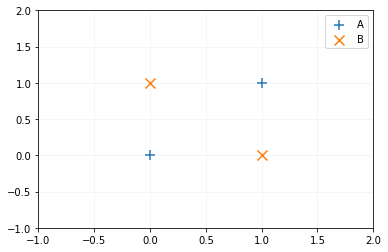

```python
import warnings
warnings.filterwarnings('ignore')
import numpy as np
import matplotlib.pyplot as plt
%matplotlib inline

x_data = np.array([[0, 0], [1, 1], [0, 1], [1, 0]], dtype=np.float32)
y_data = np.array([[0], [0], [1], [1]], dtype=np.float32)

plt.scatter(x_data[:2,0], x_data[:2,1], marker='+', s=100, label='A')
plt.scatter(x_data[2:,0], x_data[2:,1], marker='x', s=100, label='B')
plt.xlim([-1, 2]); plt.ylim([-1, 2]); plt.grid(alpha=0.15); plt.legend();
plt.show()
```

```
[[ 1.49881654e-04]
 [-8.52732244e-05]]
```

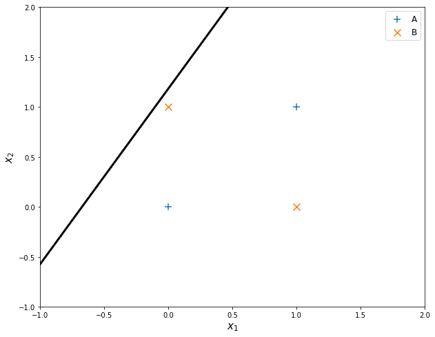

```python
# solution
from sklearn.neural_network import MLPClassifier

clf = MLPClassifier(solver='lbfgs', hidden_layer_sizes=(), activation = 'tanh', max_iter = 100000, learning_rate_init = 0.05)
clf.fit(x_data, y_data)

w_hat = clf.coefs_[0]
b_hat = clf.intercepts_[0]
print(w_hat)


x1p = np.arange(-1, 2, 0.01).reshape(-1, 1)
x2p = - w_hat[0,0]/w_hat[1,0]*x1p - b_hat[0]/w_hat[1,0]

plt.figure(figsize=(10, 8))
plt.scatter(x_data[:2,0], x_data[:2,1], marker='+', s=100, label='A')
plt.scatter(x_data[2:,0], x_data[2:,1], marker='x', s=100, label='B')
plt.legend()

plt.plot(x1p, x2p, 'k', linewidth = 3, label = '')
plt.xlim([0, 8])
plt.xlabel('$x_1$', fontsize = 15)
plt.ylabel('$x_2$', fontsize = 15)
plt.legend(loc = 1, fontsize = 12)
plt.ylim(-1, 2)
plt.xlim(-1, 2)
plt.show()
```

2) Classify the given four points in 2D plane using two perceptron layers as shown below.

Note that bias units are not indicated here.

```
[[11.12697296  4.58781512]
 [11.04119089  4.70794598]]
```

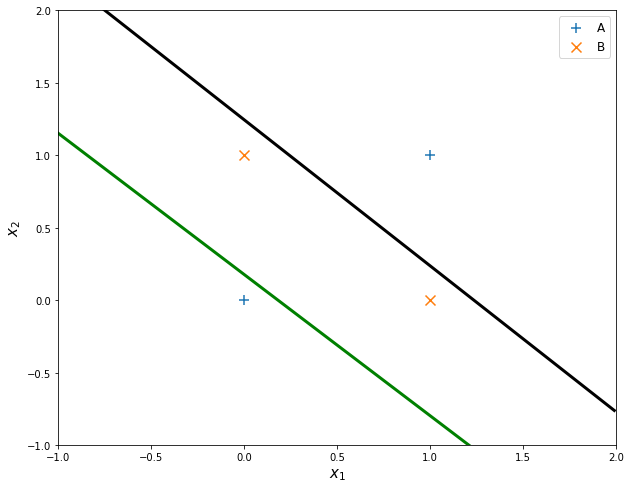

```
[0. 0. 1. 1.]
[[0.]
 [0.]
 [1.]
 [1.]]
```

```python
# Solution
from sklearn.neural_network import MLPClassifier

clf = MLPClassifier(solver='lbfgs',
                    activation='logistic',
                    alpha=0.0,
                    hidden_layer_sizes=(2,),
                    learning_rate_init=0.1,
                    max_iter=1000,
                    random_state=20)
clf.fit(x_data, y_data)


w_hat = clf.coefs_[0]
b_hat = clf.intercepts_[0]
print(w_hat)


x1p = np.arange(-1, 2, 0.01).reshape(-1, 1)
x2p = - w_hat[0,0]/w_hat[1,0]*x1p - b_hat[0]/w_hat[1,0]
x3p = - w_hat[0,1]/w_hat[1,1]*x1p - b_hat[1]/w_hat[1,1]

plt.figure(figsize=(10, 8))
plt.scatter(x_data[:2,0], x_data[:2,1], marker='+', s=100, label='A')
plt.scatter(x_data[2:,0], x_data[2:,1], marker='x', s=100, label='B')


plt.plot(x1p, x2p, 'k', linewidth = 3, label = '')
plt.plot(x1p, x3p, 'g', linewidth = 3, label = '')
plt.xlim([0, 8])
plt.xlabel('$x_1$', fontsize = 15)
plt.ylabel('$x_2$', fontsize = 15)
plt.legend(loc = 1, fontsize = 12)
plt.ylim(-1, 2)
plt.xlim(-1, 2)
plt.show()
print(clf.predict(x_data))
print(y_data)
```

# Problem 2: Kernel Space

1) In the problem 1-2), the first perceptron layer can be seen as kernel function $\phi$. Show the location of four points on 2D plane after the first layer.

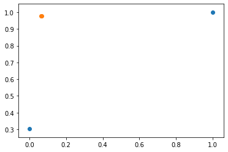

```python
# Solution

w_hat = np.asmatrix(w_hat)

results = x_data*w_hat + b_hat
results = 1/(1 + np.exp(-results))
plt.scatter([results[0:2,0]], [results[:2,1]], label = '0')
plt.scatter([results[2:,0]], [results[2:,1]], label = '1')
```

2) Visualize the kernel space onto 2D plane.

$\;\;\,$ Hint: Make 2d grid points and apply kernel.

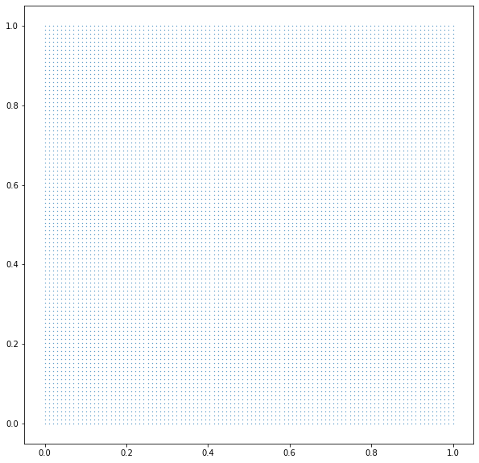

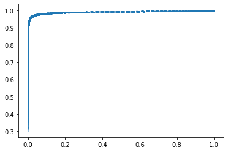

```python
# Solution
xp = np.linspace(0, 1, 100)
yp = np.linspace(0, 1, 100)
grid = np.meshgrid(xp, yp)
grid = np.asarray(grid)
plt.figure(figsize = (10,10))
plt.scatter(grid[0][:], grid[1][:], s = 0.1)
plt.show()
grid = grid.reshape(2, 10000).T
results = grid*w_hat + b_hat
results = 1/(1 + np.exp(-results))
plt.scatter([results[:,0]], [results[:,1]], s = 1)
plt.show()
```

3) Plot the decision boundary on kernel space.

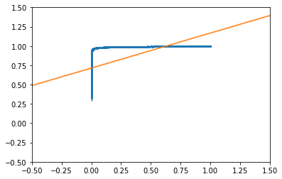

```python
# Solution

w_hat = clf.coefs_[1]
b_hat = clf.intercepts_[1]
xp = np.linspace(-0.5,1.5, 1000).reshape(-1,1)
yp = - w_hat[0,0]/w_hat[1,0]*xp - b_hat[0]/w_hat[1,0]
plt.scatter([results[:,0]], [results[:,1]], s = 1)

plt.scatter(xp, yp, s = 0.1)

plt.ylim(-0.5, 1.5)
plt.xlim(-0.5, 1.5)
plt.show()
```

# Problem 3

We are going to do 3 classes classification. The class of each digit is devided according to the remainder divided by 3. Plot the random images and labels

(ex., 0 $\Rightarrow$ class 0, 1 $\Rightarrow$ class 1, 2 $\Rightarrow$ class 2, 3 $\Rightarrow$ class 0, 4 $\Rightarrow$ class 1,, $\cdots$)

Let's load the dataset.

- Download data files
  - [mnist_train_images](https://www.dropbox.com/s/n3i8s3sgjfv523l/mnist_train_images_rev.npy?dl=1)
  - [mnist_train_labels](https://www.dropbox.com/s/ja4hss746rheq0h/mnist_train_labels_rev.npy?dl=1)
  - [mnist_test_images](https://www.dropbox.com/s/4tlm2rf5t3t3m2v/mnist_test_images_rev.npy?dl=1)
  - [mnist_test_labels](https://www.dropbox.com/s/t8fbjzsyqeotx19/mnist_test_labels_rev.npy?dl=1)

```python
import numpy as np
import matplotlib.pyplot as plt
%matplotlib inline

mnist_train_images = np.load('./data_files/mnist_train_images_rev.npy')
mnist_train_labels = np.load('./data_files/mnist_train_labels_rev.npy')
mnist_test_images = np.load('./data_files/mnist_test_images_rev.npy')
mnist_test_labels = np.load('./data_files/mnist_test_labels_rev.npy')

train_labels = mnist_train_labels
train_imgs = mnist_train_images
test_labels = mnist_test_labels
test_imgs = mnist_test_images
```

```
Train labels : [1]
```

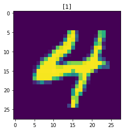

```
Train labels : [2]
```

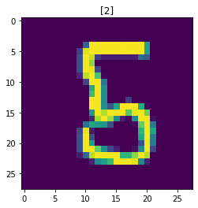

```
Train labels : [2]
```

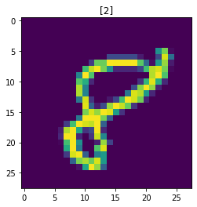

```python
# Solution
def one_hot(label):
    if label % 3 == 0:
        return [0]
    elif label % 3 == 1:
        return [1]
    else:
        return [2]
train_label = []
test_label = []
for i in train_labels:
    train_label.append(one_hot(i))
for i in test_labels:
    test_label.append(one_hot(i))

idxs = np.random.randint(0, train_imgs.shape[0], 3)
for idx in idxs:
    print ('Train labels : {}'.format(train_label[idx]))
    plt.imshow(train_imgs[idx].reshape(28,28))
    plt.title(train_label[idx])
    plt.show()
```

2) Make your own ANN model that classifies MNIST images into 3 classes.

```python
# Solution
from sklearn.neural_network import MLPClassifier

clf =MLPClassifier(solver='lbfgs',
                    activation='logistic',
                    alpha=0.0,
                    hidden_layer_sizes=(200,100,3),
                    learning_rate_init=0.1,
                    max_iter=1000,
                    random_state=20,
                  verbose = True)
```

3) Train your model and check its accuracy

```python
clf.fit(train_imgs, train_label)
```

```
MLPClassifier(activation='logistic', alpha=0.0, batch_size='auto', beta_1=0.9,
              beta_2=0.999, early_stopping=False, epsilon=1e-08,
              hidden_layer_sizes=(200, 100, 3), learning_rate='constant',
              learning_rate_init=0.1, max_iter=1000, momentum=0.9,
              n_iter_no_change=10, nesterovs_momentum=True, power_t=0.5,
              random_state=20, shuffle=True, solver='lbfgs', tol=0.0001,
              validation_fraction=0.1, verbose=True, warm_start=False)
```

```python
# Solution
prediction = clf.predict(test_imgs)
acc = 0
for i, el in enumerate(test_label):
    if el[0] == prediction[i]:
        acc += 1
print('accuracy : ', acc)
```

```
accuracy :  81
```

# Problem 4

1) Make an autoencoder model where latent space is 10-D with the MNIST dataset.

```python
# Solution
from sklearn.neural_network import MLPRegressor
from sklearn.metrics import accuracy_score
n_input = 28*28

# Encoder structure
n_encoder1 = 500
n_encoder2 = 300

n_latent = 10

# Decoder structure

n_decoder2 = 300
n_decoder1 = 500
```

```python
reg = MLPRegressor(hidden_layer_sizes = (n_encoder1, n_encoder2, n_latent,n_decoder2, n_decoder1),
                   activation = 'relu',
                   solver = 'adam',
                   learning_rate_init = 0.001,
                   max_iter = 50,
                   tol = 0.0000001,
                   verbose = True)
```

```python
reg.fit(train_imgs, train_imgs)
```

```
Iteration 1, loss = 0.05175498
Iteration 2, loss = 0.03672419
Iteration 3, loss = 0.03343499
Iteration 4, loss = 0.03264830
Iteration 5, loss = 0.03159329
Iteration 6, loss = 0.03040583
Iteration 7, loss = 0.02933288
Iteration 8, loss = 0.02832702
Iteration 9, loss = 0.02748395
Iteration 10, loss = 0.02672123
Iteration 11, loss = 0.02587993
Iteration 12, loss = 0.02514577
Iteration 13, loss = 0.02455875
Iteration 14, loss = 0.02405265
Iteration 15, loss = 0.02362321
Iteration 16, loss = 0.02316544
Iteration 17, loss = 0.02265605
Iteration 18, loss = 0.02210781
Iteration 19, loss = 0.02152645
Iteration 20, loss = 0.02103471
Iteration 21, loss = 0.02065037
Iteration 22, loss = 0.02030806
Iteration 23, loss = 0.01992858
Iteration 24, loss = 0.01957816
Iteration 25, loss = 0.01923995
Iteration 26, loss = 0.01894078
Iteration 27, loss = 0.01865836
Iteration 28, loss = 0.01836551
Iteration 29, loss = 0.01809749
Iteration 30, loss = 0.01783240
Iteration 31, loss = 0.01761170
Iteration 32, loss = 0.01739798
Iteration 33, loss = 0.01720804
Iteration 34, loss = 0.01701696
Iteration 35, loss = 0.01681754
Iteration 36, loss = 0.01665564
Iteration 37, loss = 0.01647596
Iteration 38, loss = 0.01634737
Iteration 39, loss = 0.01619842
Iteration 40, loss = 0.01610277
Iteration 41, loss = 0.01595307
Iteration 42, loss = 0.01580687
Iteration 43, loss = 0.01565029
Iteration 44, loss = 0.01553352
Iteration 45, loss = 0.01540242
Iteration 46, loss = 0.01529185
Iteration 47, loss = 0.01517617
Iteration 48, loss = 0.01507523
Iteration 49, loss = 0.01498855
Iteration 50, loss = 0.01488218
```

```
MLPRegressor(activation='relu', alpha=0.0001, batch_size='auto', beta_1=0.9,
             beta_2=0.999, early_stopping=False, epsilon=1e-08,
             hidden_layer_sizes=(500, 300, 10, 300, 500),
             learning_rate='constant', learning_rate_init=0.001, max_iter=50,
             momentum=0.9, n_iter_no_change=10, nesterovs_momentum=True,
             power_t=0.5, random_state=None, shuffle=True, solver='adam',
             tol=1e-07, validation_fraction=0.1, verbose=True,
             warm_start=False)
```

2) Show 5 random reconstructed images.

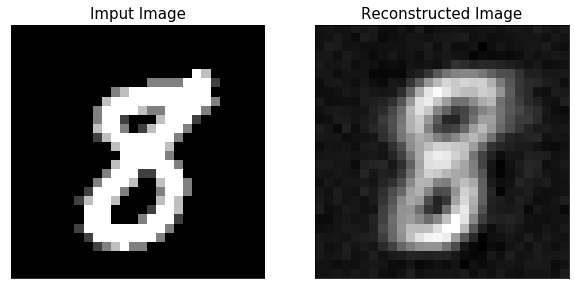

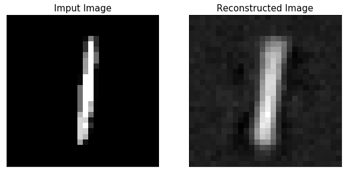

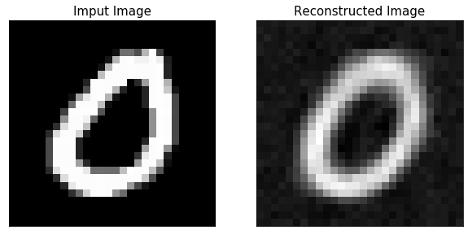

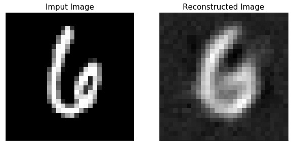

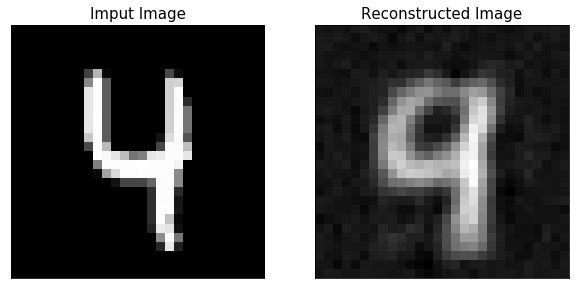

```python
# Solution
idxs = np.random.randint(0, test_imgs.shape[0], 5)
for idx in idxs:
    x_reconst = reg.predict(test_imgs[idx].reshape(-1,784))

    plt.figure(figsize = (10,8))
    plt.subplot(1,2,1)
    plt.imshow(test_imgs[idx].reshape(28,28), 'gray')
    plt.title('Imput Image', fontsize = 15)
    plt.xticks([])
    plt.yticks([])
    plt.subplot(1,2,2)
    plt.imshow(x_reconst.reshape(28,28), 'gray')
    plt.title('Reconstructed Image', fontsize = 15)
    plt.xticks([])
    plt.yticks([])
    plt.show()
```

3) Classify 10 digit classes by using MLP on latent space. Note that accurary above 65% is good enough.

```python
from sklearn.neural_network import MLPClassifier
from tensorflow.examples.tutorials.mnist import input_data
mnist = input_data.read_data_sets("MNIST_data/", one_hot=False)

mnist_train_images = np.load('./data_files/mnist_train_images_rev.npy')
mnist_train_labels = np.load('./data_files/mnist_train_labels_rev.npy')
mnist_test_images = np.load('./data_files/mnist_test_images_rev.npy')
mnist_test_labels = np.load('./data_files/mnist_test_labels_rev.npy')

train_labels = mnist_train_labels
train_imgs = mnist_train_images
test_labels = mnist_test_labels
test_imgs = mnist_test_images

def encoder(data):
    data = np.asmatrix(data)

    encoder1 = data*reg.coefs_[0] + reg.intercepts_[0]
    encoder1 = (np.exp(encoder1) - np.exp(-encoder1))/(np.exp(encoder1) + np.exp(-encoder1))

    encoder2 = encoder1*reg.coefs_[1] + reg.intercepts_[1]
    encoder2 = (np.exp(encoder2) - np.exp(-encoder2))/(np.exp(encoder2) + np.exp(-encoder2))

    latent = encoder2*reg.coefs_[2] + reg.intercepts_[2]
    latent = (np.exp(latent) - np.exp(-latent))/(np.exp(latent) + np.exp(-latent))

    return np.asarray(latent)
latent = []
for i in train_imgs:
    latent.append(encoder(i))

latent = np.asarray(latent).reshape(1000,n_latent)
```

[output not shown]

```python
clf = MLPClassifier(solver='lbfgs',
                    activation='logistic',
                    alpha=0.0,
                    hidden_layer_sizes=(50,),
                    learning_rate_init=0.1,
                    max_iter=1000,
                    random_state=20,
                  verbose = True)

clf.fit(latent, train_labels)
```

```
MLPClassifier(activation='logistic', alpha=0.0, batch_size='auto', beta_1=0.9,
              beta_2=0.999, early_stopping=False, epsilon=1e-08,
              hidden_layer_sizes=(50,), learning_rate='constant',
              learning_rate_init=0.1, max_iter=1000, momentum=0.9,
              n_iter_no_change=10, nesterovs_momentum=True, power_t=0.5,
              random_state=20, shuffle=True, solver='lbfgs', tol=0.0001,
              validation_fraction=0.1, verbose=True, warm_start=False)
```

```python
test_latent = []
for i in test_imgs:
    test_latent.append(encoder(i))

test_latent = np.asarray(test_latent).reshape(100,n_latent)

prediction = clf.predict(test_latent)
acc = 0
for i, el in enumerate(test_labels):
    if el == prediction[i]:
        acc += 1
print('accuracy : ', acc)
```

```
accuracy :  69
```